# Lista 2 AED

Tomás Ferranti

07/04/2020

Para a realização dessa lista, foram utilizados os pacotes “ggpubr”, “readxl” e “ggplot2”.

# Capítulo 2

## Questão 3

**Para o Conjunto de Dados 1 (CD-Brasil), construa a distribuição de freqüências para as variáveis população urbana e densidade populacional.**

```r
#População Urbana
dadosPopUrb <- cd_brasil$pop_urbana
dadosPopUrb <- dadosPopUrb[!is.na(dadosPopUrb)]
print("Dados da população urbana:")
```

```
## [1] "Dados da população urbana:"
```

```r
table(cut(dadosPopUrb, breaks=8, dig.lab = 8))
```

```
##
## (142682.06,4123644.8] (4123644.8,8073012.5]  (8073012.5,12022380]
##                    19                     5                     0
##   (12022380,15971748]   (15971748,19921116]   (19921116,23870484]
##                     2                     0                     0
##   (23870484,27819851]   (27819851,31800814]
##                     0                     1
```

```r
#Densidade Populacional
dadosDensi <- cd_brasil$densidade
dadosDensi <- dadosDensi[-c(10,29)]
dadosDensi <- sub(",",".",dadosDensi)
dadosDensi <- as.numeric(dadosDensi)
print("Dados da densidade:")
```

```
## [1] "Dados da densidade:"
```

```r
table(cut(dadosDensi, breaks=8, dig.lab = 5))
```

```
##
## (-0.2219,166.34]  (166.34,331.58]  (331.58,496.81]  (496.81,662.05]
##               24                2                0                0
##  (662.05,827.29]  (827.29,992.53]  (992.53,1157.8]  (1157.8,1324.3]
##                0                0                0                1
```

## Questão 8

**Construa um histograma, um ramo-e-folhas e um gráfico de dispersão unidimensional para o conjunto de dados 2 (CD-Municípios).**

Histograma:

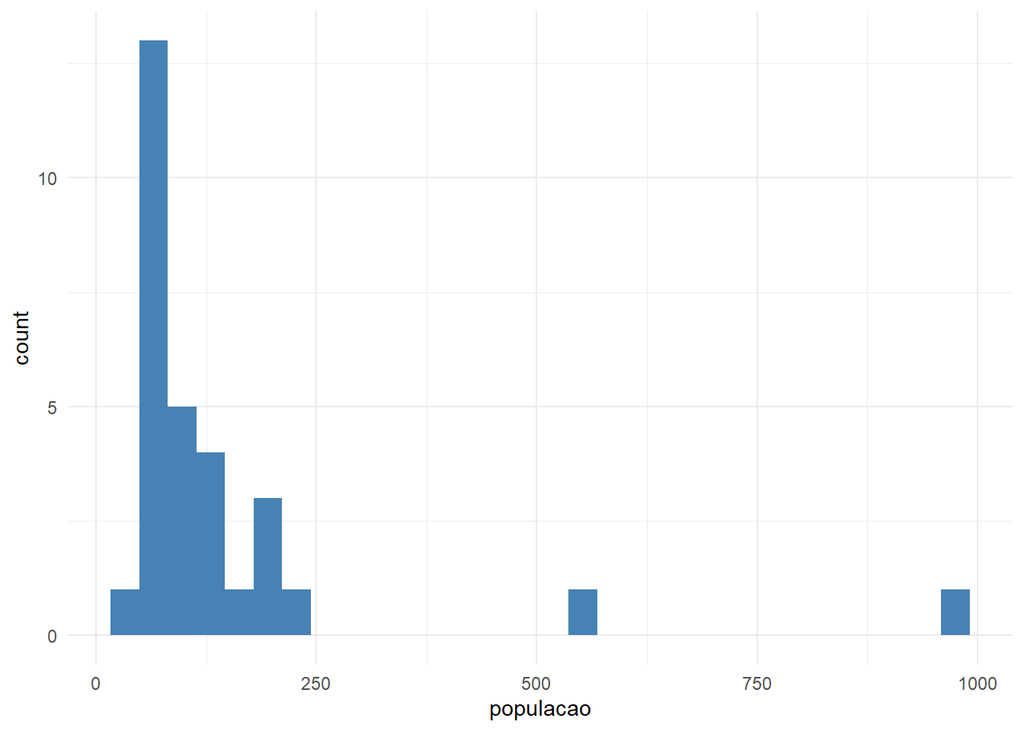

```r
ggplot(cd_municipios,aes(x=populacao)) + stat_bin(fill="steelblue",bins=30) + theme_minimal()
```

Ramo-e-folhas:

```r
stem(cd_municipios$populacao)
```

```
##
##   The decimal point is 2 digit(s) to the right of the |
##
##   0 | 55556666777778889
##   1 | 00223459
##   2 | 012
##   3 |
##   4 |
##   5 | 6
##   6 |
##   7 |
##   8 |
##   9 | 9
```

Dispersão unidimensional:

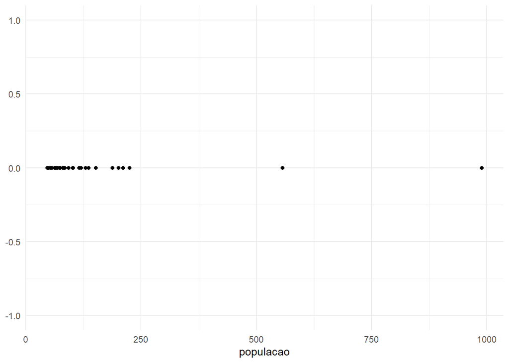

```r
ggplot(cd_municipios,aes(x=populacao)) + geom_point(fill="steelblue",y=0) + ylim(-1,1) + theme_minimal()
```

## Questão 20

**Construa um ramo-e-folhas para a variável CO (monóxido de carbono) do conjunto de dados 4 (CD-Poluição).**

```r
stem(cd_poluicao$co)
```

```
##
##   The decimal point is at the |
##
##    4 | 77
##    5 | 12
##    5 | 55677789
##    6 | 1111122222222233333444444
##    6 | 5666677777899999999
##    7 | 00122233444
##    7 | 5566777778888899999999
##    8 | 012334
##    8 | 55678999
##    9 | 0114
##    9 | 557
##   10 | 1333
##   10 | 8
##   11 | 4
##   11 | 69
##   12 | 0
##   12 | 5
```

# Capítulo 3

## Questão 18

**Considere o CD-Municípios e tome somente os 15 maiores, relativamente à sua população. Calcule q(0.1), q(0.2), q1, q2, q3.**

```r
dados = cd_municipios[1:15,]
quantis = quantile(dados$populacao,probs = c(0.1,0.2,0.25,0.5,0.75))
quantis
```

```
##    10%    20%    25%    50%    75%
##  96.16 102.20 109.15 135.80 206.20
```

## Questão 42

**Calcule o desvio absoluto mediano para as populações do CD-Brasil.**

Considerando as populações totais, temos:

```r
dadosPopTot <- cd_brasil$total
dadosPopTot <- dadosPopTot[-c(10,29)]
mediana <- median(dadosPopTot)
dam <- median(abs(dadosPopTot-mediana))
print(paste("O desvio absoluto mediano é",dam))
```

```
## [1] "O desvio absoluto mediano é 2072537"
```

## Questão 43

**Calcule as principais medidas de posição e dispersão (incluindo a média aparada e o dam) para: (a) variável CO no CD-Poluição; (b) salários de mecânicos, CD-Salários; e (c) variável preço, CD-Veículos.**

```r
dadosItemA = cd_poluicao$co
dadosItemA <- sort(dadosItemA)
cd_salarios <- readxl::read_excel("Dados_EB.xls",sheet = "CD-Salarios", range = "C6:C35")
dadosItemB = melt(cd_salarios)$value
```

```
## Using  as id variables
```

```r
dadosItemB <- sort(dadosItemB)
dadosItemC = cd_veiculos$preco
dadosItemC <- sort(dadosItemC)
aparacao = 0.10
```

Item (a):

```r
data.43a <- summary(dadosItemA)
data.43a <- c(data.43a,(((length(dadosItemA)-1)/length(dadosItemA))*var(dadosItemA))^(1/2))
n1A = floor(length(dadosItemA)*aparacao/2)
n2A = ceiling(length(dadosItemA)*(1-aparacao/2))
data.43a <- c(data.43a,mean(dadosItemA[n1A:n2A]))
data.43a <- c(data.43a,median(abs(dadosItemA-median(dadosItemA))))
names(data.43a) <- c(names(data.43a)[names(data.43a)!=""],"Desvio Padrão","Média Aparada","DAM")
data.43a
```

```
##          Min.       1st Qu.        Median          Mean       3rd Qu.
##      4.700000      6.300000      7.200000      7.464167      8.025000
##          Max. Desvio Padrão Média Aparada           DAM
##     12.500000      1.537465      7.342202      0.900000
```

```r
data.43b <- summary(dadosItemB)
data.43b <- c(data.43b,(((length(dadosItemB)-1)/length(dadosItemB))*var(dadosItemB))^(1/2))
n1B = floor(length(dadosItemB)*aparacao/2)
n2B = ceiling(length(dadosItemB)*(1-aparacao/2))
data.43b <- c(data.43b,mean(dadosItemB[n1B:n2B]))
data.43b <- c(data.43b,median(abs(dadosItemB-median(dadosItemB))))
names(data.43b) <- c(names(data.43b)[names(data.43b)!=""],"Desvio Padrão","Média Aparada","DAM")
data.43b
```

```
##          Min.       1st Qu.        Median          Mean       3rd Qu.
##       1730.00       8650.00      15916.00      18314.83      25950.00
##          Max. Desvio Padrão Média Aparada           DAM
##      39946.00      11484.75      17542.29       9342.00
```

```r
data.43c <- summary(dadosItemC)
data.43c <- c(data.43c,(((length(dadosItemC)-1)/length(dadosItemC))*var(dadosItemC))^(1/2))
n1C = floor(length(dadosItemC)*aparacao/2)
n2C = ceiling(length(dadosItemC)*(1-aparacao/2))
data.43c <- c(data.43c,mean(dadosItemC[n1C:n2C]))
data.43c <- c(data.43c,median(abs(dadosItemC-median(dadosItemC))))
names(data.43c) <- c(names(data.43c)[names(data.43c)!=""],"Desvio Padrão","Média Aparada","DAM")
data.43c
```

```
##          Min.       1st Qu.        Median          Mean       3rd Qu.
##      5257.000      7751.500     11824.000     13956.100     15255.000
##          Max. Desvio Padrão Média Aparada           DAM
##     38850.000      8490.431     13097.690      4063.000
```

## Questão 44

**Construa os histogramas, ramo-e-folhas e desenhos esquemáticos para as variáveis do problema anterior.**

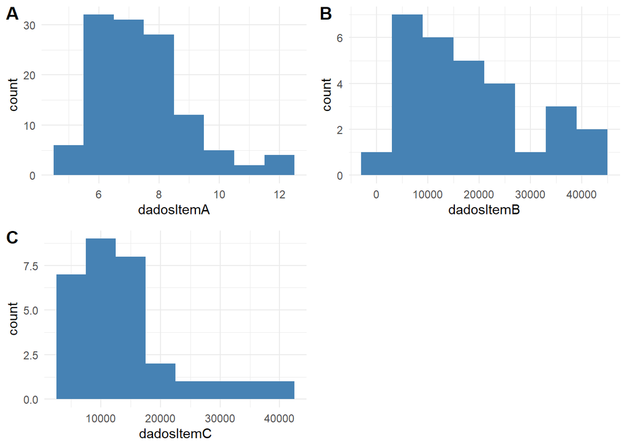

```r
histA <- ggplot(data.frame(dadosItemA),aes(x=dadosItemA)) + geom_histogram(fill="steelblue",stat='bin',binwidth = 1) + theme_minimal()
histB <- ggplot(data.frame(dadosItemB),aes(x=dadosItemB)) + geom_histogram(fill="steelblue",stat='bin',binwidth = 6000) + theme_minimal()
histC <- ggplot(data.frame(dadosItemC),aes(x=dadosItemC)) + geom_histogram(fill="steelblue",stat='bin',binwidth = 5000) + theme_minimal()
figure <- ggarrange(histA, histB, histC,
                    labels = c("A", "B", "C"),
                    ncol = 2, nrow = 2)
print(figure)
```

```r
stem(dadosItemA)
```

```
##
##   The decimal point is at the |
##
##    4 | 77
##    5 | 12
##    5 | 55677789
##    6 | 1111122222222233333444444
##    6 | 5666677777899999999
##    7 | 00122233444
##    7 | 5566777778888899999999
##    8 | 012334
##    8 | 55678999
##    9 | 0114
##    9 | 557
##   10 | 1333
##   10 | 8
##   11 | 4
##   11 | 69
##   12 | 0
##   12 | 5
```

```r
stem(dadosItemB)
```

```
##
##   The decimal point is 4 digit(s) to the right of the |
##
##   0 | 24
##   0 | 566789
##   1 | 012234
##   1 | 678
##   2 | 004
##   2 | 666
##   3 | 3
##   3 | 567
##   4 | 00
```

```r
stem(dadosItemC)
```

```
##
##   The decimal point is 4 digit(s) to the right of the |
##
##   0 | 56666678899
##   1 | 11122333444
##   1 | 66
##   2 | 22
##   2 | 5
##   3 | 24
##   3 | 9
```

## Questão 46

**Para o CD-Temperaturas e para a variável temperatura de Ubatuba, obtenha um gráfico de quantis e um gráfico de simetria. Os dados são simétricos? Comente.**

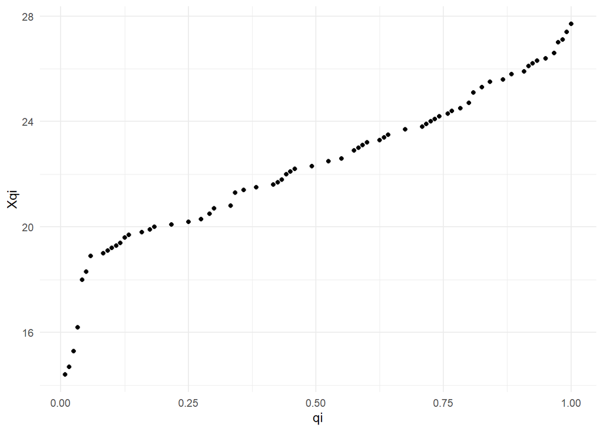

```r
dados46 = cd_temperaturas$ubatuba
dados46 <- sort(dados46)
#Gráfico de quantis
dadosPlot <- table(dados46)
dadosPlot <- cumsum(dadosPlot)
dadosPlot <- dadosPlot/dadosPlot[length(dadosPlot)]
qi = as.numeric(dadosPlot)
Xqi = as.numeric(names(dadosPlot))
ggplot(data.frame(qi,Xqi),aes(x=qi,y=Xqi)) + geom_point(fill="steelblue") + theme_minimal()
```

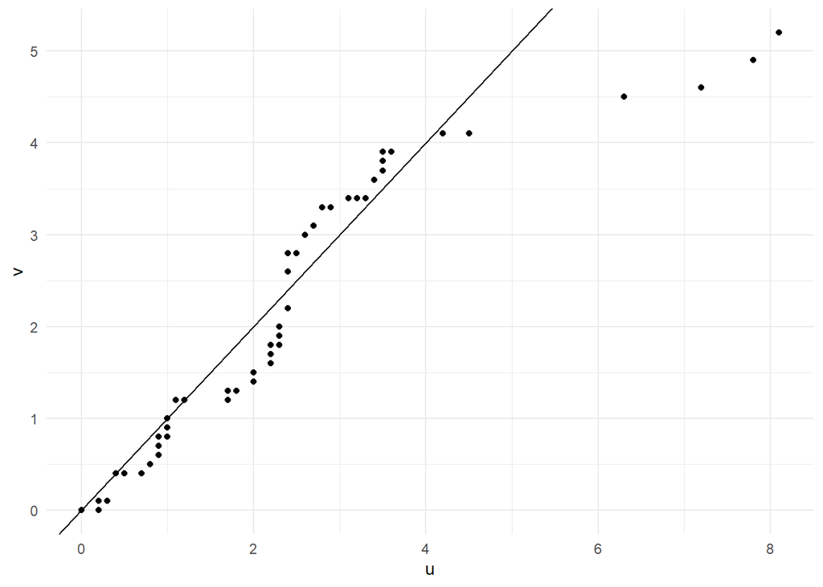

```r
#Gráfico de simetria
u = vector()
v = vector()
n = length(dados46) #n par
q2 = quantile(dados46,probs = 0.5)
for(i in 1:(n/2)){
  u[i] = q2 - dados46[n/2-i+1]
  v[i] = dados46[n/2+i] - q2
}
x <- c(0:8)
y <- x
ggplot(data.frame(u,v),aes(x=u,y=v)) + geom_point(fill="steelblue") + geom_abline(slope=1,intercept=c(0,0)) + theme_minimal()
```

```r
#lines(x,y)
```

# Capítulo 4

## Questão 37

**Analise a população total do CD-Brasil, segundo as regiões geográficas.**

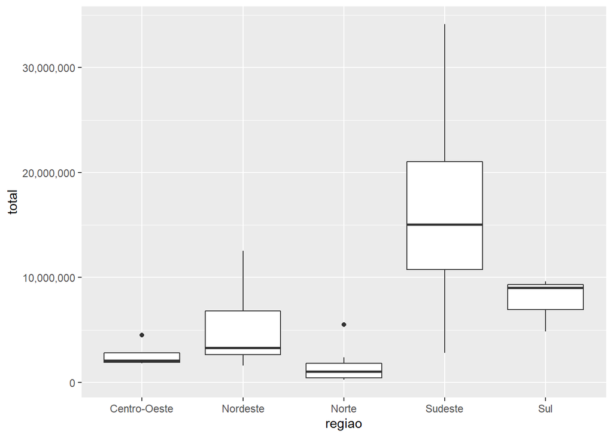

```r
dados37 <- cd_brasil[!is.na(cd_brasil$total),]
ggplot(dados37,aes(x=regiao,y=total)) + geom_boxplot() + scale_y_continuous(labels = scales::comma)
```

## Questão 39

**Considere o CD-Poluição e as variáveis CO, temperatura e umidade. Faça gráficos de dispersão para pares de variáveis. Quais conclusões você pode obter?**

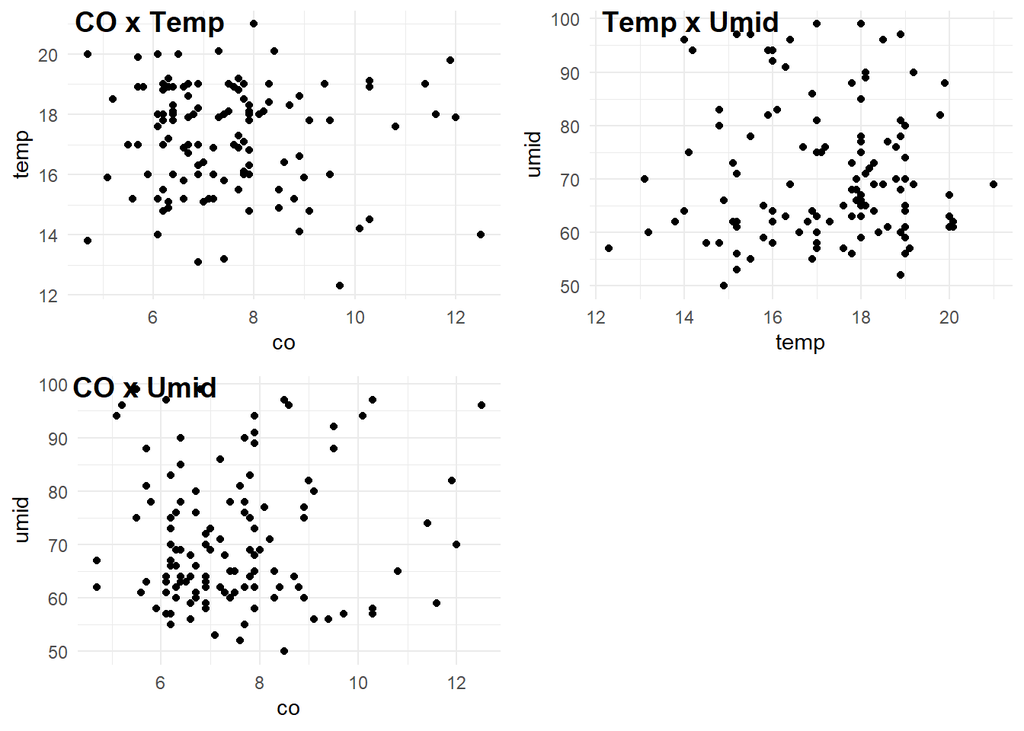

```r
q39a <- ggplot(cd_poluicao,aes(x=co,y=temp)) + geom_point(fill="steelblue") + theme_minimal()
q39b <- ggplot(cd_poluicao,aes(x=temp,y=umid)) + geom_point(fill="steelblue") + theme_minimal()
q39c <- ggplot(cd_poluicao,aes(x=co,y=umid)) + geom_point(fill="steelblue") + theme_minimal()
figure <- ggarrange(q39a, q39b, q39c,
                    labels = c("CO x Temp", "Temp x Umid", "CO x Umid"),
                    ncol = 2, nrow = 2)
print(figure)
```